# 可視化テスト

Notebook DBからNotebookをQUERYし、可視化してみるサンプル。

# リソースの定義

## DBアクセス用関数

Pythonで実装してみる。

```python
import psycopg2
import sys
import json
import os
import tempfile
import shutil
import nbformat
import io

def retrieve_notebooks_by_xpath(psql_url, xpaths, work_dir):
    conds = ["xpath('" + xpath + "', cells)::text[] <> '{}'" for xpath in xpaths]
    files = []
    memes = set()
    with connect(psql_url) as conn:
        with conn.cursor() as cur:
            cur.execute("SELECT id, server, path, content, mtime, atime " +
                        "FROM notebooks WHERE " + " and ".join(conds))
            for r in cur:
                nid, server, path, content, mtime, atime = r
                p = os.path.join(work_dir, path)
                base, _ = os.path.split(p)
                os.makedirs(base, exist_ok=True)
                files.append((nid, (nid, mtime, atime, server, p, path)))
                with open(p, 'w') as f:
                    json.dump(content, f)
        with conn.cursor() as cur:
            cur.execute("SELECT meme FROM memes WHERE notebook_id IN " +
                        '(' + ','.join([str(nid) for nid, e in files]) + ')')
            for r in cur:
                meme, = r
                memes.add(meme)
    return ([e for nid, e in files], memes)

def retrieve_notebooks_by_meme(psql_url, memes, work_dir):
    nids = set()
    with connect(psql_url) as conn:
        with conn.cursor() as cur:
            cur.execute("SELECT notebook_id FROM memes WHERE meme IN " +
                        '(' + ','.join(["'{}'".format(meme) for meme in memes]) + ')')
            for r in cur:
                notebook_id, = r
                nids.add(notebook_id)
    files = []
    memes = set()
    with connect(psql_url) as conn:
        with conn.cursor() as cur:
            cur.execute("SELECT id, server, path, content, mtime, atime " +
                        "FROM notebooks WHERE id IN " + '(' + ','.join([str(nid) for nid in nids]) + ')')
            for r in cur:
                nid, server, path, content, mtime, atime = r
                p = os.path.join(work_dir, path)
                base, _ = os.path.split(p)
                os.makedirs(base, exist_ok=True)
                files.append((nid, (nid, mtime, atime, server, p, path)))
                with open(p, 'w') as f:
                    json.dump(content, f)
        with conn.cursor() as cur:
            cur.execute("SELECT meme FROM memes WHERE notebook_id IN " +
                        '(' + ','.join([str(nid) for nid, e in files]) + ')')
            for r in cur:
                meme, = r
                memes.add(meme)
    return ([e for nid, e in files], memes)

def connect(psql_url):
    conn = psycopg2.connect(psql_url)
    conn.set_client_encoding('utf8')
    return conn
```

## DB認証情報

PostgreSQLコンテナにアクセスするための情報はNotebook環境に定義されているものとする。

```python
psql_url = !bash -c 'source ~/.secret/.psql-creds; echo $DB_URL'
psql_url = psql_url[0]
len(psql_url)
```

```
55
```

## 一時ディレクトリ

作業用に・・・

```python
import tempfile
work_dir = tempfile.mkdtemp()
work_dir
```

```
'/tmp/tmpgez_bk0b'
```

# NotebookのQuery

## Notebook

XPathでクエリしてみる。DataFrameはPandasで管理する。

```python
#!sudo /opt/conda3/bin/pip install pytz
```

```python
import pandas as pd
```

以下のようなXPathで、特定の条件を満たすセルを抽出できる。

```
"//source/item[contains(text(), \"ansible\")]/../../cell_type[text() = \"code\"]"
"//outputs//text/item[contains(text(), \"yazawa.keys\")]"
"//source/item[contains(text(), \"svg\")]/../../cell_type[text() = \"code\"]"
```

(複数のXPathをlistで指定すると、AND条件で検索される)

```python
query = ["//source/item[contains(text(), \"ironic\")]/../../cell_type[text() = \"code\"]"]
query
```

```
['//source/item[contains(text(), "ironic")]/../../cell_type[text() = "code"]']
```

```python
notebooks, memes = retrieve_notebooks_by_xpath(psql_url, query, work_dir)
df = pd.DataFrame(notebooks, columns=['ID', 'MTime', 'ATime', 'Server', 'Path', 'Name'])
df = df.sort_index()
df
```

|  | ID | MTime | ATime | Server | Path | Name |
| --- | --- | --- | --- | --- | --- | --- |
| 0 | 12 | 2017-02-08 11:32:46.535993 | 2018-03-02 06:15:59.717913 | http://cloud-jupyter.ecloud.nii.ac.jp/nii-clou... | /tmp/tmpgez_bk0b/MaruokaNotebook/ABC/3.ABC_Rec... | MaruokaNotebook/ABC/3.ABC_RecoveryManual/R04_A... |
| 1 | 14 | 2017-02-08 11:32:47.464001 | 2018-03-02 06:16:01.333927 | http://cloud-jupyter.ecloud.nii.ac.jp/nii-clou... | /tmp/tmpgez_bk0b/MaruokaNotebook/ABC/3.ABC_Rec... | MaruokaNotebook/ABC/3.ABC_RecoveryManual/R05_A... |
| 2 | 18 | 2017-02-08 11:32:49.332016 | 2018-03-02 06:16:02.973940 | http://cloud-jupyter.ecloud.nii.ac.jp/nii-clou... | /tmp/tmpgez_bk0b/MaruokaNotebook/ABC/3.ABC_Rec... | MaruokaNotebook/ABC/3.ABC_RecoveryManual/R06c_... |
| ... | ... | ... | ... | ... | ... | ... |
| 1292 | 6834 | 2017-02-24 05:26:17.000000 | 2018-02-26 20:15:49.044068 | http://deployvm1.abc/ | /tmp/tmpgez_bk0b/03_notebook_evidence/05_devid... | 03_notebook_evidence/05_devide/2.ABC_Operation... |

1293 rows × 6 columns

取得したセルが持つMEMEと同じMEMEを持つNotebookを抽出する。

```python
notebooks_m, memes_m = retrieve_notebooks_by_meme(psql_url, memes, work_dir)
df_m = pd.DataFrame(notebooks_m, columns=['ID', 'MTime', 'ATime', 'Server', 'Path', 'Name'])
df_m = df_m.sort_index()
df_m
```

|  | ID | MTime | ATime | Server | Path | Name |
| --- | --- | --- | --- | --- | --- | --- |
| 0 | 192 | 2017-12-21 02:57:00.269218 | 2018-03-02 06:41:32.442764 | http://cloud-jupyter.ecloud.nii.ac.jp/nii-clou... | /tmp/tmpgez_bk0b/YazawaNotebook/201712/2017122... | YazawaNotebook/201712/20171221_01_NetworkSegme... |
| 1 | 905 | 2018-02-09 04:02:10.786758 | 2018-02-26 20:00:26.232047 | http://cloud-jupyter.ecloud.nii.ac.jp/nii-clou... | /tmp/tmpgez_bk0b/NakagawaNotebook/20180209_04_... | NakagawaNotebook/20180209_04_ABC-CentOSマシンへのsn... |
| 2 | 953 | 2018-02-08 04:30:52.319672 | 2018-02-26 20:00:26.444049 | http://cloud-jupyter.ecloud.nii.ac.jp/nii-clou... | /tmp/tmpgez_bk0b/NakagawaNotebook/20180208_03_... | NakagawaNotebook/20180208_03_ABC-CentOSマシンへのMe... |
| ... | ... | ... | ... | ... | ... | ... |
| 828 | 6812 | 2017-10-25 02:51:25.055176 | 2018-02-26 20:15:48.870068 | http://deployvm1.abc/ | /tmp/tmpgez_bk0b/nii_hijikata/20171025-test-de... | nii_hijikata/20171025-test-detach-default_GW_n... |

829 rows × 6 columns

```python
#df = pd.concat([df, df_m])
#df
```

```python
mtime_filenames = []
for mtime, name in df[['MTime', 'Name']].values:
    mtime_filenames.append((mtime, os.path.split(name)[1]))
(len(mtime_filenames), len(set(mtime_filenames)))
```

```
(1293, 975)
```

```python
items = []
for mtime, name in set(mtime_filenames):
    sdf = df[(df['MTime'] == mtime) & (df['Name'].str.endswith(name))]
    assert len(sdf) > 0
    items.append(sdf.sort_values('ATime').values[-1])
sdf = pd.DataFrame(items, columns=df.columns)
sdf
```

|  | ID | MTime | ATime | Server | Path | Name |
| --- | --- | --- | --- | --- | --- | --- |
| 0 | 1641 | 2017-06-15 01:59:03.000000 | 2018-02-26 20:00:09.640266 | http://deployvm1.abc/ | /tmp/tmpgez_bk0b/nii_yazawa/2017-04-19_2016-06... | nii_yazawa/2017-04-19_2016-06-06_Arack_deploy/... |
| 1 | 3765 | 2017-07-12 11:13:22.908000 | 2018-03-01 20:03:14.194079 | http://deployvm3.abc/ | /tmp/tmpgez_bk0b/nii_maruoka/2017-07-12_Force1... | nii_maruoka/2017-07-12_Force10調査/2017-06-29/20... |
| 2 | 5112 | 2017-10-31 09:11:23.221628 | 2018-02-26 20:00:50.671301 | http://deployvm1.abc/ | /tmp/tmpgez_bk0b/nii_maruoka/2017-10-31_02_複数イ... | nii_maruoka/2017-10-31_02_複数インスタンス起動時のエラー対応/Op... |
| ... | ... | ... | ... | ... | ... | ... |
| 974 | 5735 | 2017-03-30 00:00:01.000000 | 2018-03-01 20:19:08.645473 | http://deployvm3.abc/ | /tmp/tmpgez_bk0b/ntt-sw_working_files/work_yam... | ntt-sw_working_files/work_yamaguchi/notebook_2... |

975 rows × 6 columns

```python
df = sdf
```

検索結果を頻度で眺めると以下のようになる。

```python
%matplotlib inline
```

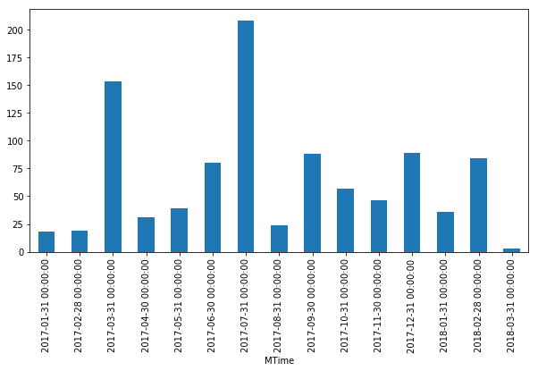

```python
ax = df.set_index('MTime').resample('1M').count()[['Name']].plot(kind='bar', figsize=(10, 5))
ax.legend_.remove()
```

## 関連情報

得られたNotebookに関するMEME, ユーザ, 対象, リソースを抽出しておく。

```python
items = []
with connect(psql_url) as conn:
    for nid in df['ID'].values:
        with conn.cursor() as cur:
            cur.execute("SELECT meme FROM memes WHERE notebook_id = %s", (str(nid),))
            for r in cur:
                items.append((nid, r[0]))
memes_df = pd.DataFrame(items, columns=['ID', 'MEME'])
memes_df
```

|  | ID | MEME |
| --- | --- | --- |
| 0 | 3765 | 35c33414-55a3-11e7-b0b2-00163e9c0e35 |
| 1 | 3765 | c008b922-5833-11e7-b0b2-00163e9c0e35 |
| 2 | 3765 | c008bcf6-5833-11e7-b0b2-00163e9c0e35 |
| ... | ... | ... |
| 64917 | 6155 | 7d3873c0-a361-11e7-a7d2-00163e9c0e35 |

64918 rows × 2 columns

```python
items = []
with connect(psql_url) as conn:
    for nid in df['ID'].values:
        with conn.cursor() as cur:
            cur.execute("SELECT organization, name FROM users WHERE notebook_id = %s", (str(nid),))
            for r in cur:
                org, name = r
                items.append((nid, org, name))
users_df = pd.DataFrame(items, columns=['ID', 'Organization', 'Name'])
users_df
```

|  | ID | Organization | Name |
| --- | --- | --- | --- |
| 0 | 1641 | nii | yazawa |
| 1 | 3765 | nii | maruoka |
| 2 | 5112 | nii | maruoka |
| ... | ... | ... | ... |
| 755 | 6155 | nii | maruoka |

756 rows × 3 columns

```python
items = []
with connect(psql_url) as conn:
    for nid in df['ID'].values:
        with conn.cursor() as cur:
            cur.execute("SELECT DISTINCT name FROM resources WHERE notebook_id = %s", (str(nid),))
            for r in cur:
                items.append((nid, r[0]))
resources_df = pd.DataFrame(items, columns=['ID', 'Name'])
resources_df
```

|  | ID | Name |
| --- | --- | --- |
| 0 | 1641 | $temp_dir/ct_act_packages.yml |
| 1 | 1641 | $temp_dir/ct_sby_packages.yml |
| 2 | 5461 | $temp_dir/ct_packages.yml |
| ... | ... | ... |
| 290 | 1671 | $temp_dir/ct_sby_packages.yml |

291 rows × 2 columns

```python
items = []
with connect(psql_url) as conn:
    for nid in df['ID'].values:
        with conn.cursor() as cur:
            cur.execute("SELECT DISTINCT name FROM targets WHERE notebook_id = %s", (str(nid),))
            for r in cur:
                items.append((nid, r[0]))
targets_df = pd.DataFrame(items, columns=['ID', 'Name'])
targets_df
```

|  | ID | Name |
| --- | --- | --- |
| 0 | 1641 | 10.17.254.1 |
| 1 | 1641 | 10.17.254.129 |
| 2 | 5112 | 10.19.254.136 |
| ... | ... | ... |
| 2714 | 5735 | 10.17.6.91 |

2715 rows × 2 columns

```python
notebooks_meme = 0
for nid in df['ID'].values:
    if len(memes_df[memes_df['ID'] == nid]) > 0:
        notebooks_meme += 1
print('{} notebooks have meme / {} notebooks'.format(notebooks_meme, len(df)))
```

```
475 notebooks have meme / 975 notebooks
```

# NotebookのVisualize

以下の3種類の距離関数を使ってNotebookを可視化してみる。

```python
#!sudo /opt/conda3/bin/pip install networkx
```

```python
import networkx as nx
import itertools
import matplotlib.pyplot as plt
from matplotlib import font_manager
from matplotlib import cm
```

## Notebook間距離なし

作成者とNotebookの関係のみ。

```python
import datetime
import numpy as np

def calc_weight_by_time(t):
    pt = datetime.datetime.now() - t
    return 0.9 ** np.log(pt / datetime.timedelta(days=7))
```

```python
def render_notebooks(filename, distance=None, iterations=10, notebook_label=True):
    g = nx.Graph()

    ids = []
    users = set()
    for t, (nid, mtime, path, name) in zip(df.index, df[['ID', 'MTime', 'Path', 'Name']].values):
        udf = users_df[users_df['ID'] == nid]
        if len(udf) == 0:
            continue
        g.add_node(nid, node_type='notebook')
        ids.append(nid)
        for org, user in udf[['Organization', 'Name']].values:
            uid = '{}#{}'.format(org, user)
            if uid not in users:
                g.add_node(uid, node_type='user')
                users.add(uid)
            g.add_edge(nid, uid, weight=calc_weight_by_time(mtime))
    if distance is not None:
        for i, nid1 in enumerate(ids):
            for nid2 in ids[i + 1:]:
                weight = distance(nid1, nid2)
                if weight is not None:
                    g.add_edge(nid1, nid2, weight=weight)

    color_map = []
    labels = {}
    attrs = nx.get_node_attributes(g, 'node_type')
    for node in g:
        node_type = attrs[node]
        if node_type == 'notebook':
            if notebook_label:
                path = df[df['ID'] == node]['Path'].values[0]
                labels[node] = os.path.splitext(os.path.split(path)[1])[0]
            else:
                labels[node] = ''
        else:
            labels[node] = node
        if node_type == 'notebook':
            color_map.append(0 / 3.0)
        elif node_type == 'user':
            color_map.append(1 / 3.0)
        elif node_type == 'resource':
            color_map.append(2 / 3.0)
        elif node_type == 'target':
            color_map.append(3 / 3.0)
        else:
            assert False
    edge_color = []
    for n1, n2 in g.edges:
        node_type1 = attrs[n1]
        node_type2 = attrs[n2]
        if node_type1 == 'notebook' and node_type1 == node_type2:
            edge_color.append(0.0)
        else:
            edge_color.append(1.0)

    fontprop = font_manager.FontProperties(fname='/usr/share/fonts/truetype/fonts-japanese-gothic.ttf', size='small')
    user_fontprop = font_manager.FontProperties(fname='/usr/share/fonts/truetype/fonts-japanese-gothic.ttf', size='large')

    plt.figure(figsize=(30, 30))
    pos = nx.spring_layout(g, iterations=iterations)
    nx.draw_networkx_nodes(g, pos, node_color=color_map, cmap='Set2')
    text_items = nx.draw_networkx_labels(g, pos, labels)
    for node in g:
        node_type = attrs[node]
        if node_type == 'user':
            text_items[node].set_fontproperties(user_fontprop)
        else:
            text_items[node].set_fontproperties(fontprop)
    nx.draw_networkx_edges(g, pos, alpha=0.5, edge_color=edge_color, edge_cmap=cm.get_cmap('Set1'),
                           edge_vmin=0.0, edge_vmax=1.0)

    plt.axis("off")
    plt.savefig(filename, transparent=True)
    plt.show()
```

```python
render_notebooks('notebooks-20180306-norel.svg', iterations=60, notebook_label=False)
```

[output not shown]

## 距離関数 - MEME

Cellに含まれるmemeにもとづいて距離を決定する。

```python
def distance_by_meme(nid1, nid2):
    meme1 = set(memes_df[memes_df['ID'] == nid1]['MEME'].values)
    meme2 = set(memes_df[memes_df['ID'] == nid2]['MEME'].values)
    u = len(meme1.union(meme2))
    i = len(meme1.intersection(meme2))
    if u == 0 or i == 0:
        return None
    return i / u
```

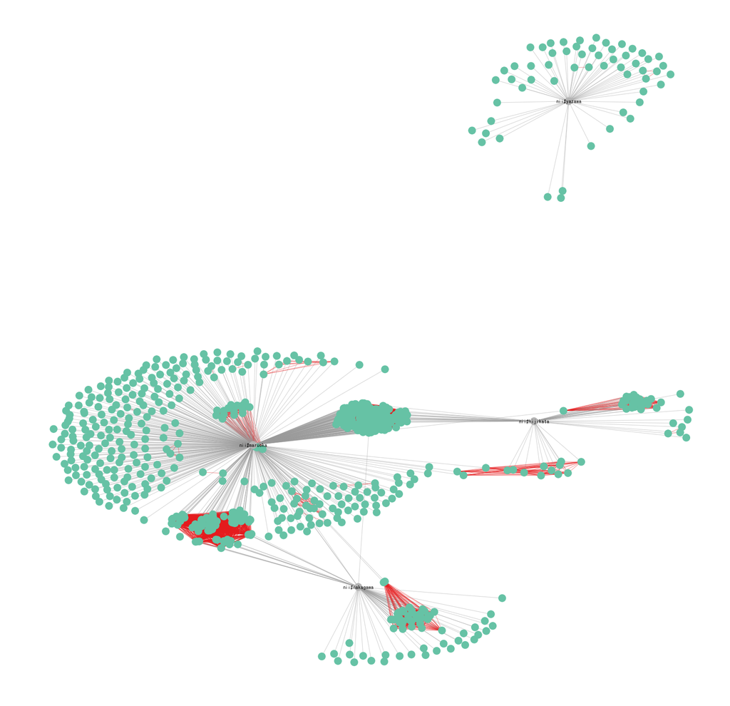

```python
render_notebooks('notebooks-20180306-meme.svg', distance=distance_by_meme, iterations=30, notebook_label=False)
```

## 距離関数 - 操作対象

Cellから操作された対象によって距離を計算する。

```python
def distance_by_target(nid1, nid2):
    target1 = set(targets_df[targets_df['ID'] == nid1]['Name'].values)
    target2 = set(targets_df[targets_df['ID'] == nid2]['Name'].values)
    u = len(target1.union(target2))
    i = len(target1.intersection(target2))
    if u == 0 or i == 0:
        return None
    return i / u
```

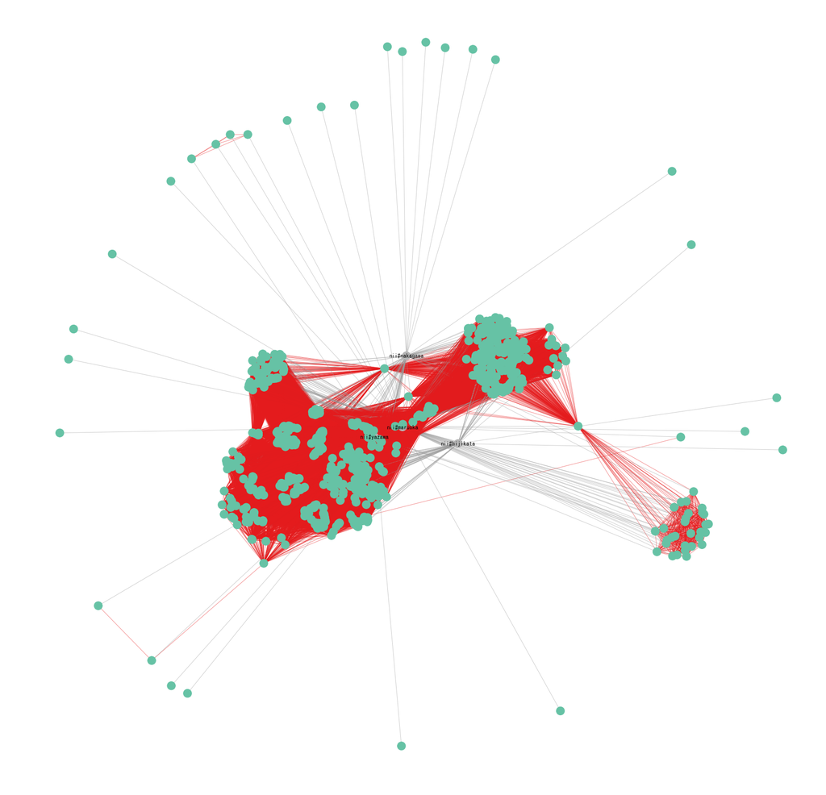

```python
render_notebooks('notebooks-20180306-target.svg', distance=distance_by_target, iterations=22, notebook_label=False)
```

## 距離関数 - 使用リソース

Cellから利用されたリソースによって距離を計算する。

```python
def distance_by_resource(nid1, nid2):
    target1 = set(resources_df[resources_df['ID'] == nid1]['Name'].values)
    target2 = set(resources_df[resources_df['ID'] == nid2]['Name'].values)
    u = len(target1.union(target2))
    i = len(target1.intersection(target2))
    if u == 0 or i == 0:
        return None
    return i / u
```

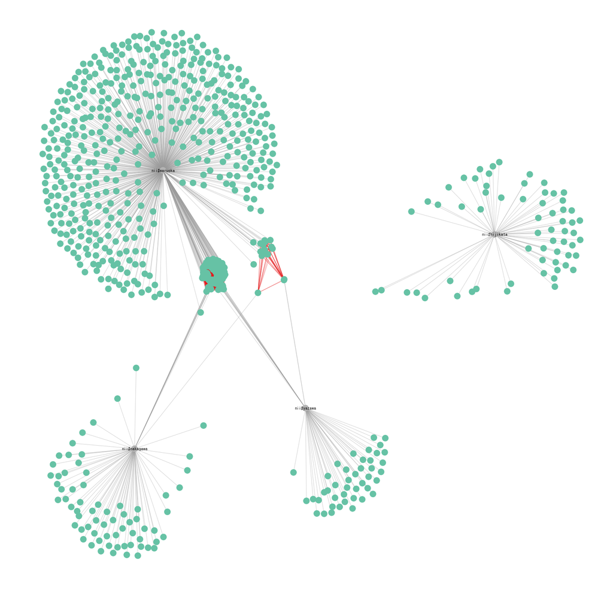

```python
render_notebooks('notebooks-20180306-resource.svg', distance=distance_by_resource, iterations=20, notebook_label=False)
```